# 4 - N-grams

2026-02-25

# N-grams and relationships between words

So far, we have been working with words as individual units. Here we will start working with n-grams: consecutive sequences of words where `n` defines the number of words composing a token.

## Working with n-grams

We make it by using the argument `token "ngrams"` in the function `unnest_tokens`.

```r
library(dplyr)
library(tidytext)
library(janeaustenr)

austen_bigrams <- austen_books() %>%
  #we take the text in austen_books, and tokenize it to sequences of 2 words
  #our usual column "word" is now "bigram"
  unnest_tokens(bigram, text, token = "ngrams", n = 2) %>%
  #we filter all N/A outputs
  filter(!is.na(bigram))

austen_bigrams
```

```
## # A tibble: 662,783 × 2
##    book                bigram
##    <fct>               <chr>
##  1 Sense & Sensibility sense and
##  2 Sense & Sensibility and sensibility
##  3 Sense & Sensibility by jane
##  4 Sense & Sensibility jane austen
##  5 Sense & Sensibility chapter 1
##  6 Sense & Sensibility the family
##  7 Sense & Sensibility family of
##  8 Sense & Sensibility of dashwood
##  9 Sense & Sensibility dashwood had
## 10 Sense & Sensibility had long
## # ℹ 662,773 more rows
```

Note that this is still a one-token-per-row dataframe, only that tokens now are composed of two words. **Each token now is a bigram, not a word**.

Also note that bigrams **overlap** here: “the family of dashwood” creates three bigrams: “the family”, “family of”, “of dashwood”. It makes all possible combinations.

**Note**: why are we filtering `N/A` outputs? Although there shouldn’t technically be any `N/A` values if the text is well-structured, in practice, they can appear due to **empty lines, insufficient words in certain sections or unusual punctuation.**

Therefore, **removing `N/A` values is a good practice** to ensure that you’re only working with valid n-grams.

We can use `count` to examine the most frequent bigrams:

```r
austen_bigrams %>%
  count(bigram, sort = TRUE)
```

```
## # A tibble: 193,209 × 2
##    bigram       n
##    <chr>    <int>
##  1 of the    2853
##  2 to be     2670
##  3 in the    2221
##  4 it was    1691
##  5 i am      1485
##  6 she had   1405
##  7 of her    1363
##  8 to the    1315
##  9 she was   1309
## 10 had been  1206
## # ℹ 193,199 more rows
```

It is tempting to filter all stopwords here. But some bigrams like `her_aunt` (page 28 of the dataframe) are composed of one stopword and one useful word. We want to keep all meaningful words. So, we need to take a previous step:

- First, we separate them in two columns using the function `separate` and the blank space as a delimiter. We save it into `bigrams_separated`.
- Second, we filter `stop_words` in both columns. We save it into `bigrams_filtered`.
- Third, we repeat the `count` to see the difference.

```r
library(tidyr)

bigrams_separated <- austen_bigrams %>%
  #we separate each bigram in two columns, word1 and word2
  separate(bigram, c("word1", "word2"), sep = " ")

bigrams_separated
```

```
## # A tibble: 662,783 × 3
##    book                word1    word2
##    <fct>               <chr>    <chr>
##  1 Sense & Sensibility sense    and
##  2 Sense & Sensibility and      sensibility
##  3 Sense & Sensibility by       jane
##  4 Sense & Sensibility jane     austen
##  5 Sense & Sensibility chapter  1
##  6 Sense & Sensibility the      family
##  7 Sense & Sensibility family   of
##  8 Sense & Sensibility of       dashwood
##  9 Sense & Sensibility dashwood had
## 10 Sense & Sensibility had      long
## # ℹ 662,773 more rows
```

```r
#remember that stop_words is a stop words list already built in R. Print it just to see it
stop_words
```

```
## # A tibble: 1,149 × 2
##    word        lexicon
##    <chr>       <chr>
##  1 a           SMART
##  2 a's         SMART
##  3 able        SMART
##  4 about       SMART
##  5 above       SMART
##  6 according   SMART
##  7 accordingly SMART
##  8 across      SMART
##  9 actually    SMART
## 10 after       SMART
## # ℹ 1,139 more rows
```

```r
#we filter all words included in each word column in stop_words
bigrams_filtered <- bigrams_separated %>%
  filter(!word1 %in% stop_words$word) %>%
  filter(!word2 %in% stop_words$word)

bigrams_filtered
```

```
## # A tibble: 38,913 × 3
##    book                word1       word2
##    <fct>               <chr>       <chr>
##  1 Sense & Sensibility jane        austen
##  2 Sense & Sensibility chapter     1
##  3 Sense & Sensibility norland     park
##  4 Sense & Sensibility surrounding acquaintance
##  5 Sense & Sensibility late        owner
##  6 Sense & Sensibility advanced    age
##  7 Sense & Sensibility constant    companion
##  8 Sense & Sensibility happened    ten
##  9 Sense & Sensibility henry       dashwood
## 10 Sense & Sensibility norland     estate
## # ℹ 38,903 more rows
```

Now, both variables (word 1 and word 2) are clean of stopwords. We repeat the count:

```r
# new bigram counts:
bigram_counts <- bigrams_filtered |>
  count(word1, word2, sort = TRUE)

bigram_counts
```

```
## # A tibble: 28,974 × 3
##    word1   word2         n
##    <chr>   <chr>     <int>
##  1 sir     thomas      266
##  2 miss    crawford    196
##  3 captain wentworth   143
##  4 miss    woodhouse   143
##  5 frank   churchill   114
##  6 lady    russell     110
##  7 sir     walter      108
##  8 lady    bertram     101
##  9 miss    fairfax      98
## 10 colonel brandon      96
## # ℹ 28,964 more rows
```

As usual in this novels, more frequent words are **proper nouns**, and most frequent bigrams are proper nouns using the title: sir, miss, lady, captain. Or name and surname combinations.

But here we still have this in two separated columns, word1 and word2. To reunite bigrams again in one single column, we use the function `unite`.

```r
bigrams_united <- bigrams_filtered %>%
  unite(bigram, word1, word2, sep = " ")

bigrams_united
```

```
## # A tibble: 38,913 × 2
##    book                bigram
##    <fct>               <chr>
##  1 Sense & Sensibility jane austen
##  2 Sense & Sensibility chapter 1
##  3 Sense & Sensibility norland park
##  4 Sense & Sensibility surrounding acquaintance
##  5 Sense & Sensibility late owner
##  6 Sense & Sensibility advanced age
##  7 Sense & Sensibility constant companion
##  8 Sense & Sensibility happened ten
##  9 Sense & Sensibility henry dashwood
## 10 Sense & Sensibility norland estate
## # ℹ 38,903 more rows
```

**Exercise**: repeat the previous sequence `tokenize-separate-filter-unite` with trigrams to extract the most frequent and relevant trigrams from Jane Austen’s novels. Remember to change `bigram` for `trigram` in variables and column names when it’s needed. **You can do it all in one cell.**

What do you see different in trigrams?

**Note**: when n-grams are all the same count, they are automatically put in alphabetical order.

### Conditional n-grams

We may want to condition the n-grams to obtain **just those containing a specific word**. In this case, we need to work with the dataframe separated in two columns and stop_words filtered.

Let’s find out which are the **most frequently named streets** in Jane Austen books.

```r
bigrams_filtered %>%
  #in English the name of the street is always word 1 and the word "street" is always word 2
  filter(word2 == "street") %>%
  count(book, word1, word2, sort = TRUE)
```

```
## # A tibble: 33 × 4
##    book                word1       word2      n
##    <fct>               <chr>       <chr>  <int>
##  1 Sense & Sensibility harley      street    16
##  2 Sense & Sensibility berkeley    street    15
##  3 Northanger Abbey    milsom      street    10
##  4 Northanger Abbey    pulteney    street    10
##  5 Mansfield Park      wimpole     street     9
##  6 Pride & Prejudice   gracechurch street     8
##  7 Persuasion          milsom      street     5
##  8 Sense & Sensibility bond        street     4
##  9 Sense & Sensibility conduit     street     4
## 10 Persuasion          rivers      street     4
## # ℹ 23 more rows
```

### Combine with TF-IDF

Likewise, we can combine n-grams analysis with TF-IDF analysis to get a very informative output. In this case, we need to work with bigrams united.

**Which are the bigrams with higher TF-IDF in Jane Austen collection?**

```r
#we use the bigrams united dataframe
bigram_tf_idf <- bigrams_united |>
  #we count by book
  count(book, bigram) |>
  #we perform tf_idf
  bind_tf_idf(bigram, book, n) |>
  #we arrange in descending order
  arrange(desc(tf_idf))

bigram_tf_idf
```

```
## # A tibble: 31,391 × 6
##    book                bigram                n     tf   idf tf_idf
##    <fct>               <chr>             <int>  <dbl> <dbl>  <dbl>
##  1 Mansfield Park      sir thomas          266 0.0304  1.79 0.0545
##  2 Persuasion          captain wentworth   143 0.0290  1.79 0.0519
##  3 Mansfield Park      miss crawford       196 0.0224  1.79 0.0402
##  4 Persuasion          lady russell        110 0.0223  1.79 0.0399
##  5 Persuasion          sir walter          108 0.0219  1.79 0.0392
##  6 Emma                miss woodhouse      143 0.0173  1.79 0.0309
##  7 Northanger Abbey    miss tilney          74 0.0165  1.79 0.0295
##  8 Sense & Sensibility colonel brandon      96 0.0155  1.79 0.0278
##  9 Sense & Sensibility sir john             94 0.0152  1.79 0.0273
## 10 Pride & Prejudice   lady catherine       87 0.0139  1.79 0.0248
## # ℹ 31,381 more rows
```

If we filter just by book, we obtain the more distinctive n-grams for each of them: bigrams that are more present in this book than in others and make it different.

```r
bigram_tf_idf |>
  filter(book=="Mansfield Park")
```

```
## # A tibble: 7,027 × 6
##    book           bigram              n      tf   idf  tf_idf
##    <fct>          <chr>           <int>   <dbl> <dbl>   <dbl>
##  1 Mansfield Park sir thomas        266 0.0304   1.79 0.0545
##  2 Mansfield Park miss crawford     196 0.0224   1.79 0.0402
##  3 Mansfield Park lady bertram      101 0.0116   1.79 0.0207
##  4 Mansfield Park henry crawford     46 0.00526  1.79 0.00943
##  5 Mansfield Park miss crawford's    44 0.00503  1.79 0.00902
##  6 Mansfield Park dr grant           40 0.00458  1.79 0.00820
##  7 Mansfield Park miss price         38 0.00435  1.79 0.00779
##  8 Mansfield Park miss bertram       37 0.00423  1.79 0.00759
##  9 Mansfield Park sir thomas's       34 0.00389  1.79 0.00697
## 10 Mansfield Park mansfield park     32 0.00366  1.79 0.00656
## # ℹ 7,017 more rows
```

Let’s plot it.

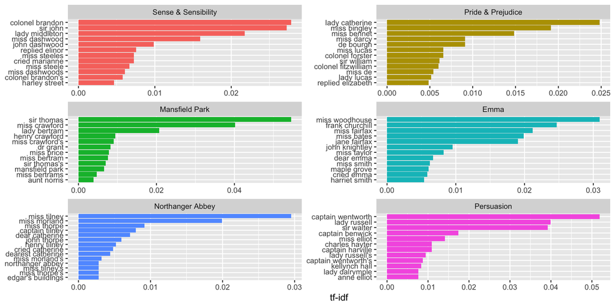

```r
library(forcats)
library(ggplot2)

bigram_tf_idf %>%
  group_by(book) %>%
  #choose maximum number of words
  slice_max(tf_idf, n = 12) %>%
  ungroup() %>%
  ggplot(aes(tf_idf, fct_reorder(bigram, tf_idf), fill = book)) +
  geom_col(show.legend = FALSE) +
  facet_wrap(~book, ncol = 2, scales = "free") +
  labs(x = "tf-idf", y = NULL)
```

Advantages of using bigrams instead of words:

- Word combinations are less frequent than single words, so bigrams can be more efficient when you have a very large corpus.
- They give us more context for a token than single words.

### Using n-grams for context

In sentiment analysis we encountered a problem when working with **negative clauses**. ‘Happy’ always means ‘happy’ unless it is preceded by ‘not’. We can use bigrams to look at the adjacent context of the word from the left.

```r
bigrams_separated |>
  filter(word1 == "not") |>
  count(word1, word2, sort = TRUE)
```

```
## # A tibble: 1,178 × 3
##    word1 word2     n
##    <chr> <chr> <int>
##  1 not   be      580
##  2 not   to      335
##  3 not   have    307
##  4 not   know    237
##  5 not   a       184
##  6 not   think   162
##  7 not   been    151
##  8 not   the     135
##  9 not   at      126
## 10 not   in      110
## # ℹ 1,168 more rows
```

Using AFINN we can see which words were negated in the Austen corpus, but were however associated to a sentiment by themselves.

Let’s make a dataframe with them making an `inner_join` as usual with AFINN:

```r
AFINN <- get_sentiments("afinn")

not_words <- bigrams_separated |>
  filter(word1 == "not") |>
  #if word2 is not in AFINN, leave it out
  inner_join(AFINN, by = c(word2 = "word")) |>
  count(word1, word2, value, sort = TRUE)

not_words
```

```
## # A tibble: 229 × 4
##    word1 word2   value     n
##    <chr> <chr>   <dbl> <int>
##  1 not   like        2    95
##  2 not   help        2    77
##  3 not   want        1    41
##  4 not   wish        1    39
##  5 not   allow       1    30
##  6 not   care        2    21
##  7 not   sorry      -1    20
##  8 not   leave      -1    17
##  9 not   pretend    -1    17
## 10 not   worth       2    17
## # ℹ 219 more rows
```

It’s worth asking which words contributed the most in the “wrong” direction. To compute that, we can multiply their value by the number of times they appear in the collection.

```r
frequent_not_words <- not_words |>
  #create a column called contribution to store mentions in the corpus x value
  mutate(contribution = n * value) |>
  #abs is for absolute values (regardless of pos or neg)
  arrange(desc(abs(contribution))) %>%
  mutate(word2 = reorder(word2, contribution)) %>%
  head(20)

frequent_not_words
```

```
## # A tibble: 20 × 5
##    word1 word2     value     n contribution
##    <chr> <fct>     <dbl> <int>        <dbl>
##  1 not   like          2    95          190
##  2 not   help          2    77          154
##  3 not   love          3    15           45
##  4 not   care          2    21           42
##  5 not   want          1    41           41
##  6 not   wish          1    39           39
##  7 not   worth         2    17           34
##  8 not   allow         1    30           30
##  9 not   afraid       -2    15          -30
## 10 not   fail         -2    14          -28
## 11 not   perfectly     3     7           21
## 12 not   sorry        -1    20          -20
## 13 not   miss         -2    10          -20
## 14 not   fair          2     9           18
## 15 not   deceive      -3     6          -18
## 16 not   despair      -3     6          -18
## 17 not   leave        -1    17          -17
## 18 not   pretend      -1    17          -17
## 19 not   refuse       -2     8          -16
## 20 not   regret       -2     8          -16
```

Let’s plot this: words associated with a sentiment but negated in context. We multiply sentiment value in AFINN by the number of occurrences.

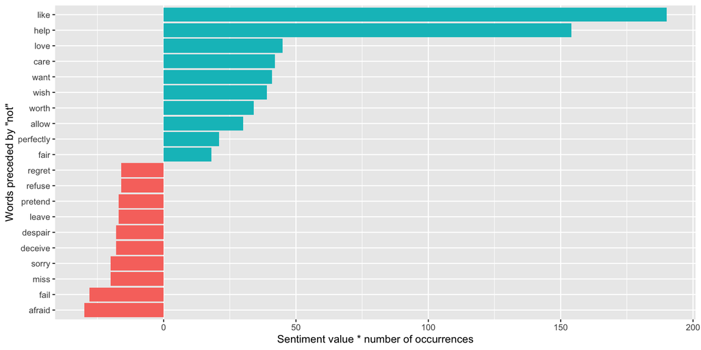

```r
library(ggplot2)

frequent_not_words |>
  ggplot(aes(n * value, word2, fill = n * value > 0)) +
  geom_col(show.legend = FALSE) +
  labs(x = "Sentiment value * number of occurrences",
       y = "Words preceded by \"not\"")
```

However, “not” is not the only negation word we have in English. Let’s create a vector with some others and create the tibble again.

```r
negation_words <- c("not", "no", "never", "without")

negated_words <- bigrams_separated |>
  filter(word1 %in% negation_words) |>
  inner_join(AFINN, by = c(word2 = "word")) |>
  count(word1, word2, value, sort = TRUE)

negated_words
```

```
## # A tibble: 503 × 4
##    word1 word2 value     n
##    <chr> <chr> <dbl> <int>
##  1 no    doubt    -1    96
##  2 not   like      2    95
##  3 not   help      2    77
##  4 no    no       -1    58
##  5 not   want      1    41
##  6 not   wish      1    39
##  7 not   allow     1    30
##  8 no    harm     -2    22
##  9 not   care      2    21
## 10 not   sorry    -1    20
## # ℹ 493 more rows
```

And now, let’s plot most common positive or negative words preceeded by a negation word, by word.

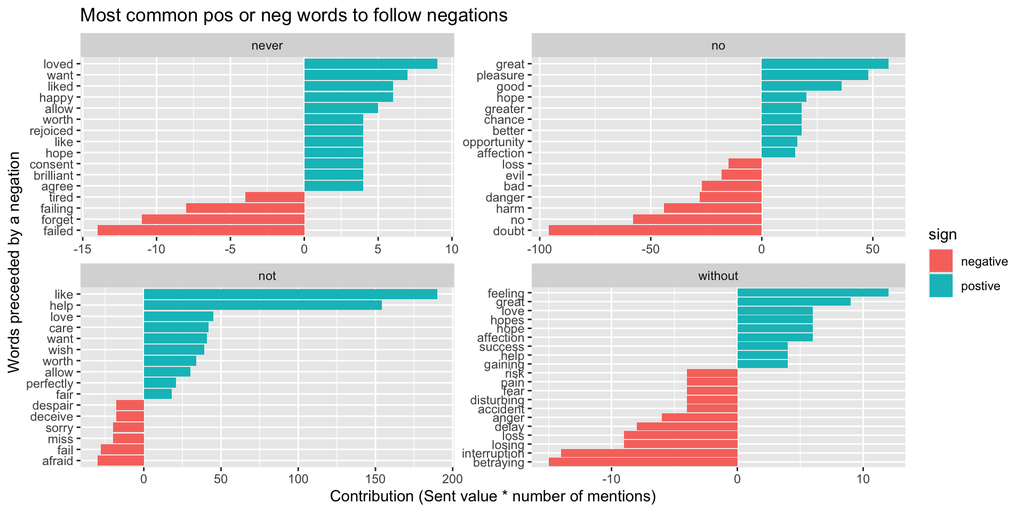

```r
negated_words %>%
  mutate(contribution = n * value,
         sign = if_else(value > 0, "postive", "negative")) %>%
  group_by(word1) %>%
  top_n(15, abs(contribution)) %>%
  ungroup() %>%
  ggplot(aes(y = reorder_within(word2, contribution, word1),
             x = contribution,
             fill = sign)) +
  geom_col() +
  scale_y_reordered() +
  facet_wrap(~ word1, scales = "free") +
  labs(y = 'Words preceeded by a negation',
       x = "Contribution (Sent value * number of mentions)",
       title = "Most common pos or neg words to follow negations")
```

### Visualizing a network of bigrams

A graph is a combination of connected nodes. Talking about text, nodes are words, and edges are the relationships they show in the corpus.

Relationships, and thus, edges, can have different numeric weights.

A graph can be constructed since it has three variables:

- **from**: the node an edge is coming from
- **to**: the node an edge is going towards
- **weight**: the numeric value associated with each edge

In this session, we already had a dataframe of Austen books without stopwords and bigrams counted. Let’s have a look again:

```r
bigram_counts
```

```
## # A tibble: 28,974 × 3
##    word1   word2         n
##    <chr>   <chr>     <int>
##  1 sir     thomas      266
##  2 miss    crawford    196
##  3 captain wentworth   143
##  4 miss    woodhouse   143
##  5 frank   churchill   114
##  6 lady    russell     110
##  7 sir     walter      108
##  8 lady    bertram     101
##  9 miss    fairfax      98
## 10 colonel brandon      96
## # ℹ 28,964 more rows
```

We have exactly the three characteristics igraph needs:

- **from**: the node an edge is coming from **(word1)**
- **to**: the node an edge is going towards **(word2)**
- **weight**: the numeric value associated with each edge **(n)**

Let’s install the library `igraph` to make a graph with it.

```r
# install.packages("igraph")
```

```r
library(igraph)
# we use the dataframe with bigram counted.
bigram_counts
```

```
## # A tibble: 28,974 × 3
##    word1   word2         n
##    <chr>   <chr>     <int>
##  1 sir     thomas      266
##  2 miss    crawford    196
##  3 captain wentworth   143
##  4 miss    woodhouse   143
##  5 frank   churchill   114
##  6 lady    russell     110
##  7 sir     walter      108
##  8 lady    bertram     101
##  9 miss    fairfax      98
## 10 colonel brandon      96
## # ℹ 28,964 more rows
```

```r
# filter by combinations with n > 20
bigram_for_graph <- bigram_counts |>
  filter(n > 20) |>
  #we use this function to create the object
  graph_from_data_frame()

#the object:
bigram_for_graph
```

```
## IGRAPH e7bb868 DN-- 85 70 --
## + attr: name (v/c), n (e/n)
## + edges from e7bb868 (vertex names):
##  [1] sir     ->thomas     miss    ->crawford   captain ->wentworth
##  [4] miss    ->woodhouse  frank   ->churchill  lady    ->russell
##  [7] sir     ->walter     lady    ->bertram    miss    ->fairfax
## [10] colonel ->brandon    sir     ->john       miss    ->bates
## [13] jane    ->fairfax    lady    ->catherine  lady    ->middleton
## [16] miss    ->tilney     miss    ->bingley    thousand->pounds
## [19] miss    ->dashwood   dear    ->miss       miss    ->bennet
## [22] miss    ->morland    captain ->benwick    miss    ->smith
## + ... omitted several edges
```

This is not the visual graph we expected to see, but is the first step. It has prepared nodes and edges to be represented.

To visualize it, we will be using `ggraph`:

```r
# install.packages("ggraph")
```

We don’t need to give `ggraph` any information, since igraph has already done that for us. We just pipe it three arguments:

- `geom_edge_link` to manage the edges,
- `geom_node_point` to manage the nodes,
- and `geom_node_text` to manage the labels.

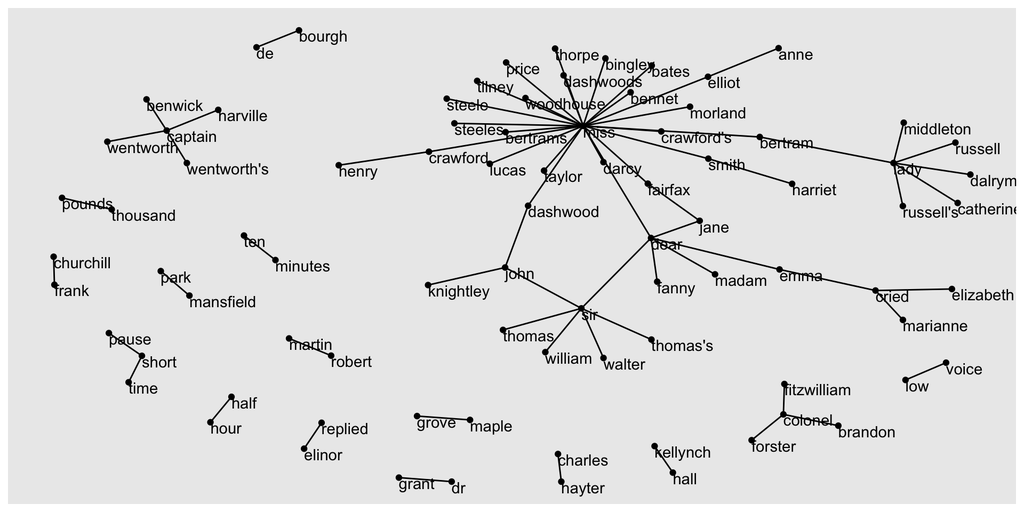

```r
library(ggraph)
set.seed(2017)

#layout is used to prevent nodes from overlapping
ggraph(bigram_for_graph, layout = "fr") +
  geom_edge_link() +
  geom_node_point() +
  geom_node_text(aes(label = name), vjust = 1, hjust = 0)
```

We can use the three arguments of ggraph to introduce settings and improve our graph:

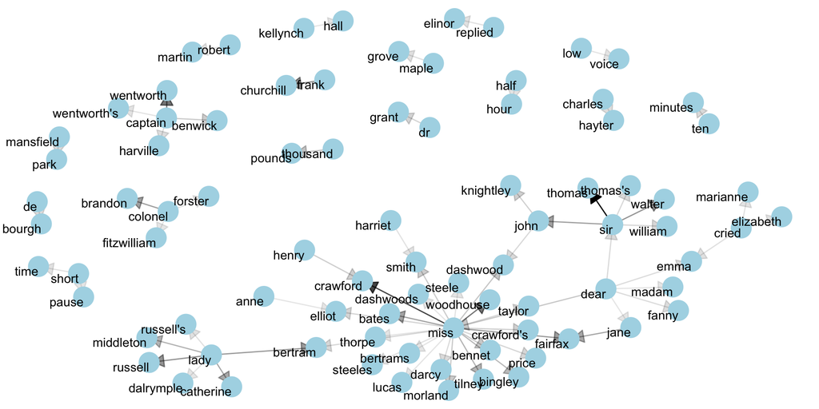

```r
set.seed(2020)

a <- grid::arrow(type = "closed", length = unit(.15, "inches"))

ggraph(bigram_for_graph, layout = "fr") +
  geom_edge_link(aes(edge_alpha = n), show.legend = FALSE,
                 arrow = a, end_cap = circle(.05, 'inches')) +
  geom_node_point(color = "lightblue", size = 8) +
  geom_node_text(aes(label = name), vjust = 1, hjust = 1) +
  theme_void()
```

We can tell now the real “to” and “from” for each edge.

### Making functions for bigram graphs

Extracting bigrams has been a long work that can be zipped in a function that takes a **dataset** as an input:

- We extract bigrams with `unnest_tokens`
- We `separate` them to filter stopwords
- We `count` how many times each bigram appears in the collection

Once we’ve got this dataframe organized in three columns, `word1`, `word2`, `n`, we can make another function for visualization:

- We use `graph_from_data_frame()` from `igraph` to prepare the bigrams to be represented in a graph.
- We use ggraph and the three arguments for nodes, edges and labels to visualize it.
- We apply cosmetic changes to make it more visible.

Let’s just define the functions.

```r
library(dplyr)
library(tidyr)
library(tidytext)
library(ggplot2)
library(igraph)
library(ggraph)

count_bigrams <- function(dataset) {
  dataset %>%
    unnest_tokens(bigram, text, token = "ngrams", n = 2) %>%
    separate(bigram, c("word1", "word2"), sep = " ") %>%
    filter(!word1 %in% stop_words$word,
           !word2 %in% stop_words$word) %>%
    filter(!is.na(word1), !is.na(word2)) %>%
    count(word1, word2, sort = TRUE)
}

visualize_bigrams <- function(bigrams) {
  set.seed(2016)
  a <- grid::arrow(type = "closed", length = unit(.15, "inches"))

  bigrams %>%
    graph_from_data_frame() %>%
    ggraph(layout = "fr") +
    geom_edge_link(aes(edge_alpha = n), show.legend = FALSE, arrow = a) +
    geom_node_point(color = "lightblue", size = 5) +
    geom_node_text(aes(label = name), vjust = 1, hjust = 1) +
    theme_void()
}
```

### Exploring bigrams

**Exercise**: using the above defined functions, visualize bigrams or trigrams for any other book in [Project Gutenberg](https://www.gutenberg.org/). From the graph, try to draw some conclusions on the book: what it is about, which are the characters, the setting, etc.

```r
library(gutenbergr)
library(dplyr)
hgwells <- gutenberg_download(c(35))
```

```
## Using mirror https://aleph.pglaf.org.
```

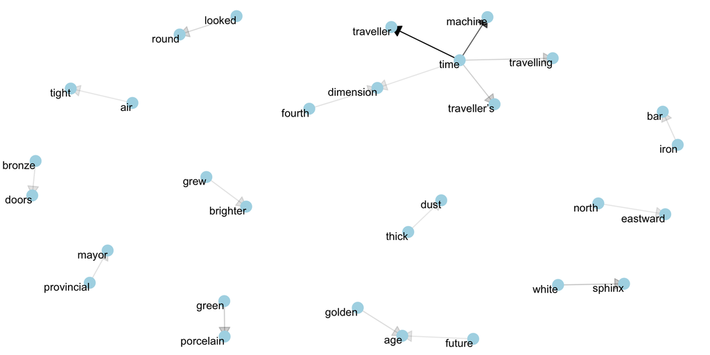

```r
hgwells_bigrams <- hgwells |>
  count_bigrams()

hgwells_bigrams |>
  filter(n > 2) |>
  visualize_bigrams()
```

## Correlating pairs of words

We have been working with pairs of adjacent words that always go together. Let’s look now to pairs of words that appear in the same context, but not necessarily together.

Let’s take *Pride and Prejudice* and split it into sections of 10 lines. We will create a dataframe with the tokenised text and a column indicating **in which section each token appears**.

```r
austen_section_words <- austen_books() |>
  filter(book == "Pride & Prejudice") |>
  mutate(section = row_number() %/% 10) |>
  filter(section > 0) |>
  unnest_tokens(word, text) |>
  filter(!word %in% stop_words$word)

austen_section_words
```

```
## # A tibble: 37,240 × 3
##    book              section word
##    <fct>               <dbl> <chr>
##  1 Pride & Prejudice       1 truth
##  2 Pride & Prejudice       1 universally
##  3 Pride & Prejudice       1 acknowledged
##  4 Pride & Prejudice       1 single
##  5 Pride & Prejudice       1 possession
##  6 Pride & Prejudice       1 fortune
##  7 Pride & Prejudice       1 wife
##  8 Pride & Prejudice       1 feelings
##  9 Pride & Prejudice       1 views
## 10 Pride & Prejudice       1 entering
## # ℹ 37,230 more rows
```

But what we really want to know is: which pairs of words appear **together across the book, in more than one section?**

The `pairwise_count()` function gives us one row for each pair of words, and the number of times they co-appeared in the same section of 10 lines. It belongs to the package `widyr`.

```r
# install.packages("widyr")
```

```r
library(widyr)
word_pairs <- austen_section_words |>
  pairwise_count(word, section, sort = TRUE)

word_pairs
```

```
## # A tibble: 796,008 × 3
##    item1     item2         n
##    <chr>     <chr>     <dbl>
##  1 darcy     elizabeth   144
##  2 elizabeth darcy       144
##  3 miss      elizabeth   110
##  4 elizabeth miss        110
##  5 elizabeth jane        106
##  6 jane      elizabeth   106
##  7 miss      darcy        92
##  8 darcy     miss         92
##  9 elizabeth bingley      91
## 10 bingley   elizabeth    91
## # ℹ 795,998 more rows
```

Filtering this dataset by item1, we can easily know what kind of words are always sharing context with the word *evening*, or *morning*, for example.

```r
word_pairs |>
  filter(item1 == "evening")
```

```
## # A tibble: 1,218 × 3
##    item1   item2         n
##    <chr>   <chr>     <dbl>
##  1 evening elizabeth    24
##  2 evening darcy        18
##  3 evening bennet       16
##  4 evening bingley      16
##  5 evening jane         13
##  6 evening passed       12
##  7 evening day          11
##  8 evening morning      11
##  9 evening family       11
## 10 evening till         10
## # ℹ 1,208 more rows
```

```r
word_pairs %>%
  filter(item1 == "morning")
```

```
## # A tibble: 1,123 × 3
##    item1   item2         n
##    <chr>   <chr>     <dbl>
##  1 morning elizabeth    32
##  2 morning bennet       21
##  3 morning day          17
##  4 morning miss         17
##  5 morning time         15
##  6 morning bingley      14
##  7 morning darcy        14
##  8 morning jane         12
##  9 morning evening      11
## 10 morning dear         10
## # ℹ 1,113 more rows
```

### Pairwise correlation

**Correlation** among words indicates how often they appear nearby relative to how often they appear separately.

To measure this correlation we will use the Phi coefficient, which is similar to the Pearson Correlation. When looking at a corpus, the Phi coefficient measures **how likely it is that two words appear together taking into account the probability for each word of appearing alone**.

This is: if a word is very common in the text, like Elizabeth, its co-occurrence rate is very high with all words in the text. But this is not real, this rate has to be pondered. Elizabeth is very likely to appear alone, so the co-ocurrence rate is not so important.

The [`pairwise_cor()`](https://juliasilge.github.io/widyr/reference/pairwise_cor.html) function in `widyr` lets us find the Phi coefficient between words.

```r
word_cors <- austen_section_words %>%
  group_by(word) %>%
  filter(n() >= 20) %>%
  pairwise_cor(word, section, sort = TRUE)

word_cors
```

```
## # A tibble: 154,842 × 3
##    item1     item2     correlation
##    <chr>     <chr>           <dbl>
##  1 bourgh    de              0.951
##  2 de        bourgh          0.951
##  3 pounds    thousand        0.701
##  4 thousand  pounds          0.701
##  5 william   sir             0.664
##  6 sir       william         0.664
##  7 catherine lady            0.663
##  8 lady      catherine       0.663
##  9 forster   colonel         0.622
## 10 colonel   forster         0.622
## # ℹ 154,832 more rows
```

This is tricky too, because the word *de* do not belong to the English language, so it is clearly part of a proper noun, and its probability of appearing alone in this corpus is very low. This makes Phi coefficient to be very high.

However, we can find **interesting correlations** too, logical like *park* and *walk*, and surprising like *money* and *marry*.

We can always go further and filter by words to see the most correlated to them:

```r
word_cors %>%
  filter(item1 == "money")
```

```
## # A tibble: 393 × 3
##    item1 item2     correlation
##    <chr> <chr>           <dbl>
##  1 money marry          0.249
##  2 money happy          0.110
##  3 money persuaded      0.103
##  4 money jane's         0.0950
##  5 money uncle          0.0872
##  6 money girl           0.0806
##  7 money wickham        0.0791
##  8 money doubt          0.0771
##  9 money fortune        0.0755
## 10 money lydia          0.0748
## # ℹ 383 more rows
```

To illustrate our analysis, we can filter by several words and plot it:

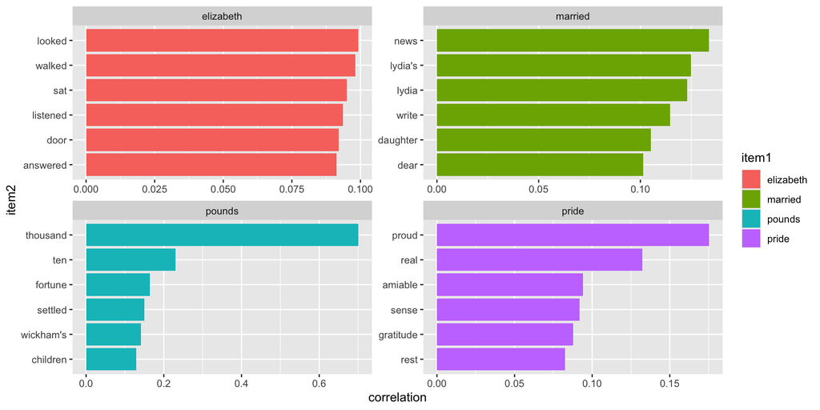

```r
word_cors %>%
  #we define a vector for 4 words
  filter(item1 %in% c("elizabeth", "pounds", "married", "pride")) %>%
  #we group by item1
  group_by(item1) %>%
  #we use the first 6 most correlated
  slice_max(correlation, n = 6) %>%
  ungroup() %>%
  #we reorder item2 regarding its correlation
  mutate(item2 = reorder(item2, correlation)) %>%
  #we plot
  ggplot(aes(item2, correlation, fill=item1)) +
  geom_bar(stat = "identity") +
  facet_wrap(~ item1, scales = "free") +
  coord_flip()
```

### Plotting correlations in a graph

Just as we used `ggraph` to visualize bigrams, we can use it to visualize the correlations and clusters of words that were found by the `widyr` package:

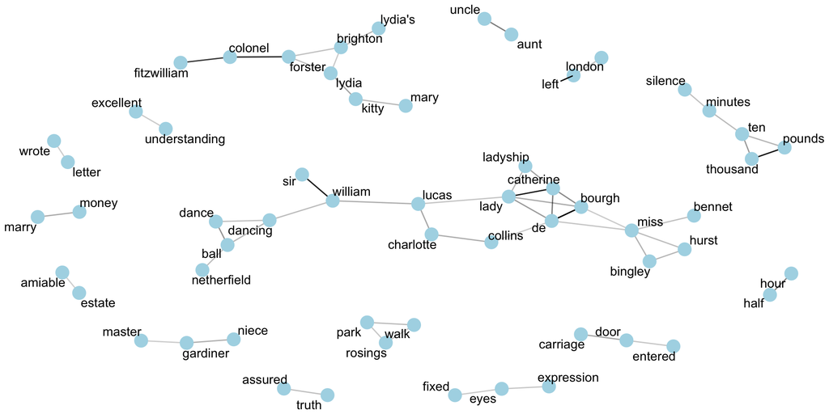

```r
set.seed(2016)

word_cors %>%
  filter(correlation > 0.18) %>% #this line is the key
  graph_from_data_frame() %>%
  ggraph(layout = "fr") +
  geom_edge_link(aes(edge_alpha = correlation), show.legend = FALSE) +
  geom_node_point(color = "lightblue", size = 5) +
  geom_node_text(aes(label = name), repel = TRUE) +
  theme_void()
```

In previous plots we were just seeing bigrams, here we are looking at all words correlations over 0.18.

**Exercise**:

There is a library in R called `friends`, providing the complete script transcription of the Friends sitcom. Let’s have a look at the transcript through bigrams and correlations. Follow the next steps:

- Install the package:

```r
library(friends)
```

- Make a plot with the most frequent bigrams. Use the functions `count_bigrams` and `visualize_bigrams` that we have built previously.

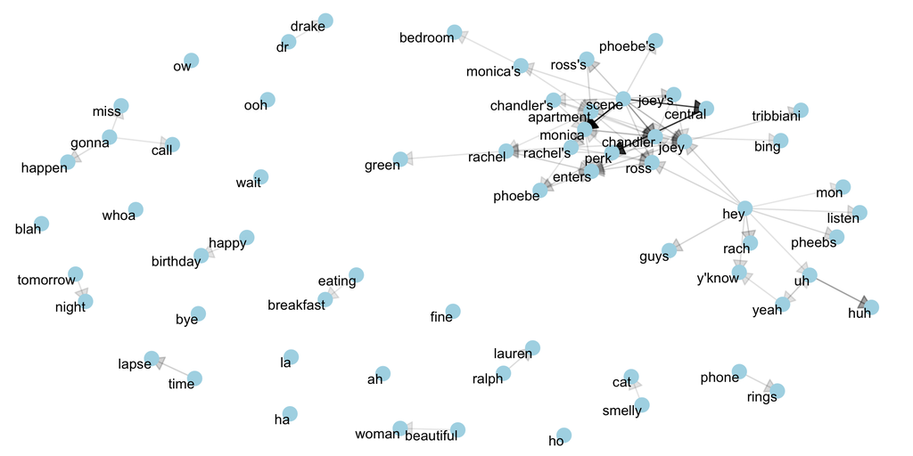

```r
friends |>
  count_bigrams() |>
  filter(n > 30) |>
  visualize_bigrams()
```

- Create a dataframe with the script splitted in sections of 10 lines, tokenize and create a column called `section` to indicate which section the word belongs to.

```r
friends_section_words <- friends |>
  mutate(section = row_number() %/% 10) |>
  filter(section > 0) %>%
  unnest_tokens(word, text) %>%
  filter(!word %in% stop_words$word)

friends_section_words
```

```
## # A tibble: 216,245 × 7
##    speaker       season episode scene utterance section word
##    <chr>          <int>   <int> <int>     <int>   <dbl> <chr>
##  1 Chandler Bing      1       1     1        10       1 alright
##  2 Chandler Bing      1       1     1        10       1 school
##  3 Chandler Bing      1       1     1        10       1 standing
##  4 Chandler Bing      1       1     1        10       1 middle
##  5 Chandler Bing      1       1     1        10       1 cafeteria
##  6 Chandler Bing      1       1     1        10       1 realize
##  7 Chandler Bing      1       1     1        10       1 totally
##  8 Chandler Bing      1       1     1        10       1 naked
##  9 #ALL#              1       1     1        11       1 yeah
## 10 #ALL#              1       1     1        11       1 dream
## # ℹ 216,235 more rows
```

- Use `pairwise_count` to create a dataframe with word pairs co-occurring most often across the script.

```r
friends_pairs <- friends_section_words |>
  pairwise_count(word, section, sort = TRUE)

friends_pairs
```

```
## # A tibble: 2,811,940 × 3
##    item1    item2        n
##    <chr>    <chr>    <dbl>
##  1 hey      yeah      1261
##  2 yeah     hey       1261
##  3 scene    monica    1236
##  4 monica   scene     1236
##  5 scene    yeah      1210
##  6 yeah     scene     1210
##  7 scene    chandler  1146
##  8 chandler scene     1146
##  9 hey      scene     1127
## 10 scene    hey       1127
## # ℹ 2,811,930 more rows
```

- Filter by one character and write down the 20 words that co-appear the most with him or her.

```r
friends_pairs |>
  filter(item1 == "phoebe")
```

```
## # A tibble: 7,918 × 3
##    item1  item2        n
##    <chr>  <chr>    <dbl>
##  1 phoebe scene      898
##  2 phoebe yeah       727
##  3 phoebe monica     681
##  4 phoebe hey        607
##  5 phoebe rachel     570
##  6 phoebe chandler   567
##  7 phoebe joey       554
##  8 phoebe ross       518
##  9 phoebe gonna      456
## 10 phoebe uh         363
## # ℹ 7,908 more rows
```

- Use `pairwise_cors` to find correlations between words instead of just co-appearances.

```r
friends_word_cors <- friends_section_words |>
  group_by(word) |>
  filter(n() >= 20) |>
  pairwise_cor(word, section, sort = TRUE)

friends_word_cors
```

```
## # A tibble: 2,272,556 × 3
##    item1       item2       correlation
##    <chr>       <chr>             <dbl>
##  1 perk        central           0.989
##  2 central     perk              0.989
##  3 lauren      ralph             0.930
##  4 ralph       lauren            0.930
##  5 c.h.e.e.s.e mac               0.774
##  6 mac         c.h.e.e.s.e       0.774
##  7 continued   earlier           0.744
##  8 earlier     continued         0.744
##  9 opera       soap              0.723
## 10 soap        opera             0.723
## # ℹ 2,272,546 more rows
```

- Filter by one character and write down the 20 words that are **most correlated with** him or her. How informative are they comparing to co-appearances?

```r
friends_word_cors |>
  filter(item1 == "phoebe")
```

```
## # A tibble: 1,507 × 3
##    item1  item2    correlation
##    <chr>  <chr>          <dbl>
##  1 phoebe scene          0.230
##  2 phoebe central        0.205
##  3 phoebe perk           0.205
##  4 phoebe monica         0.187
##  5 phoebe rachel         0.142
##  6 phoebe mike           0.127
##  7 phoebe phoebe's       0.120
##  8 phoebe pheebs         0.120
##  9 phoebe buffay         0.110
## 10 phoebe rachel's       0.109
## # ℹ 1,497 more rows
```

- Create a graph with word correlations using `ggraph`.

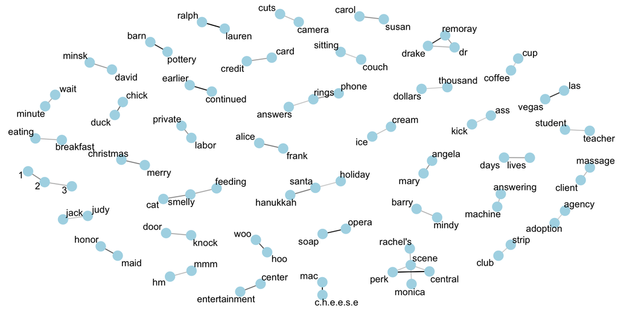

```r
set.seed(2016)

friends_word_cors |>
  filter(correlation > 0.3) |>
  graph_from_data_frame() %>%
  ggraph(layout = "fr") +
  geom_edge_link(aes(edge_alpha = correlation), show.legend = FALSE) +
  geom_node_point(color = "lightblue", size = 5) +
  geom_node_text(aes(label = name), repel = TRUE) +
  theme_void()
```

## Web news n-grams

In this exercise, we are using a sample from the [GDELT WEB Ngram Dataset](https://blog.gdeltproject.org/announcing-the-web-news-ngram-datasets-web-ngram/), which tracks frequencies of n-grams in online news from around the world. In this case, we are working with news from a **15 minutes period**.

- Each row represents a timestamp, the bigram, the language, and how often it appeared in a short interval of news coverage (count).

Let’s read it first.

```r
library(tidyverse)
file <- "webnews_bigrams_gdelt.txt"

#we read the file forcing column names
webnews <- read_tsv(file, col_names = c("datetime","lang","bigram","count"), show_col_types = FALSE)

#we filter only english bigrams and mentioned more than five times
webnews_english <- webnews %>% filter(lang == "ENGLISH", count >5)

#first glimpse of the data
tail(webnews_english)
```

```
## # A tibble: 6 × 4
##   datetime lang    bigram         count
##      <dbl> <chr>   <chr>          <dbl>
## 1  2.03e13 ENGLISH anthropic to       6
## 2  2.03e13 ENGLISH south of           6
## 3  2.03e13 ENGLISH advocate who       6
## 4  2.03e13 ENGLISH elsewhere have     6
## 5  2.03e13 ENGLISH our use            6
## 6  2.03e13 ENGLISH great in           6
```

**Exercise**: Based on this data, and using only bigrams, answer these questions:

- what topics or events do you think dominated the media agenda in this period of 15 minutes?
- which countries can you identify in the news?
- is the press abusing any words?

**Some advice:**

- Since we don’t know the data well, do not use the functions. Write specific code in this case.
- Filter stopwords
- Use this code to filter not only stopwords, but numbers and symbols too: `str_detect(word1, "^[A-Za-z]+$")`

## Summary

We have learned so far:

- How to tokenize by n-grams and count their appearances
- How to filter n-grams by a condition
- How to combine n-grams with TF-IDF
- How to use n-grams to find the context of a word, like negation in sentiment analysis
- How to visualize a graph of bigrams
- How to measure word co-appearance across contexts (sections)
- How to find correlations between pairs of words with Phi coefficient
- How to visualize correlations between words in a plot
- How to explore bigrams datasets